# DMI - Hands on 1

Maria Pau Pijoan & Leyre Roca (u269315@upf.edu)

Last update: 25 January, 2026

This practical focuses on data wrangling, exploratory data analysis, visualization, and critical comparison with published results using real biomedical data.

We will work with the publication [**Proteomic and Metabolomic Characterization of COVID-19 Patient Sera**](https://www.sciencedirect.com/science/article/pii/S0092867420306279)

# Exercise 1

Download and load Supplementary Table 1 (“Additional Demographical and Baseline Characteristics of COVID-19 Patients and Control Groups”) from the supplementary materials of the publication.

## Exercise 1.1

Reproduce Table 1 from the manuscript using the supplementary data. Match the reported summary statistics as closely as possible.

Briefly discuss any discrepancies between your results and the published table, and provide possible explanations.

```r
# -----------------------------
# Final code to reproduce Table 1 structure using table1
# -----------------------------

#install.packages(c("readxl","dplyr","stringr","readr","lubridate","table1","janitor","htmltools"))

library(readxl)
library(dplyr)
library(stringr)
library(readr)
library(lubridate)
library(table1)
library(janitor)
library(htmltools)

# 1) Read data
df <- read_excel("../1-s2.0-S0092867420306279-mmc1.xlsx", sheet = 2)
df <- clean_names(df)
# 2) Build the main Table-1 group column for ALL rows first (critical)
df <- df %>%
  mutate(
    group = case_when(
      group_d == 0 ~ "Healthy Control",
      group_d == 1 ~ "Non-COVID-19",
      group_d == 2 ~ "Non-severe",
      group_d == 3 ~ "Severe",
      TRUE ~ NA_character_
    )
  ) %>%
  filter(!is.na(group))  # removes any unexpected codes

# 3) Clean variables used in Table 1
df <- df %>%
  mutate(
    # sex coding (you confirmed: 1=Male, 0=Female)
    sex = case_when(
      sex_g == 1 ~ "Male",
      sex_g == 0 ~ "Female",
      TRUE ~ NA_character_
    ) %>% factor(levels = c("Male","Female")),

    # numeric age
    age = parse_number(as.character(age_year)),

    # numeric BMI (IMPORTANT: make it numeric, not character)
    bmi = na_if(as.character(bmi_h), "/") %>%
      str_replace_all(",", ".") %>%
      str_replace_all("[^0-9.\\-]", "") %>%
      na_if("") %>%
      parse_number(),

    # dates + time from onset to admission
    onset_date = as.Date(onset_date_f),
    admission_date = as.Date(admission_date),
    onset_to_admission = as.numeric(admission_date - onset_date),

    # progression date is stored as Excel serial numbers like 43849
    prog_num = suppressWarnings(as.numeric(na_if(as.character(date_of_progression_to_severe_state), "/"))),
    prog_date = as.Date(prog_num, origin = "1899-12-30"),

    # time from admission to severe (only meaningful for Severe)
    admission_to_severe = as.numeric(prog_date - admission_date)
  )

# 4) Add COVID-19 Total rows (duplicate Non-severe + Severe and relabel)
df_total <- df %>%
  filter(group %in% c("Non-severe", "Severe")) %>%
  mutate(group = "COVID-19 Total")

# 5) Final dataset with 5 columns for Table 1
df5 <- bind_rows(df, df_total)

df5$group <- factor(
  df5$group,
  levels = c("Healthy Control","Non-COVID-19","COVID-19 Total","Non-severe","Severe")
)

# sanity check of Ns (should be 28, 25, 65, 37, 28 if matching paper)
print(df5 %>% count(group))
```

```
## # A tibble: 5 × 2
##   group               n
##   <fct>           <int>
## 1 Healthy Control    28
## 2 Non-COVID-19       25
## 3 COVID-19 Total     65
## 4 Non-severe         37
## 5 Severe             28
```

```r
# 6) Formatting functions
my.render.cont <- function(x) {
  x <- x[!is.na(x)]
  if (length(x) == 0) return("")
  m <- mean(x); s <- sd(x)
  med <- median(x)
  q <- quantile(x, c(.25,.75))
  r <- range(x)
  sprintf("Mean ± SD: %.1f ± %.1f\nMedian (IQR): %.1f (%.1f–%.1f)\nRange: %.1f–%.1f",
          m, s, med, q[1], q[2], r[1], r[2])
}
my.render.cat <- function(x) render.categorical.default(x)

# 7) Produce Table 1 and save as HTML
t1 <- table1(
  ~ sex + age + bmi + onset_to_admission + admission_to_severe | group,
  data = df5,
  render.continuous = my.render.cont,
  render.categorical = my.render.cat,
  render.missing = NULL, #Removes the "Missing" rows
  overall = FALSE
)

t1
```

|  | Healthy Control (N=28) | Non-COVID-19 (N=25) | COVID-19 Total (N=65) | Non-severe (N=37) | Severe (N=28) |
| --- | --- | --- | --- | --- | --- |
| sex |  |  |  |  |  |
| Male | 21 (75.0%) | 17 (68.0%) | 39 (60.0%) | 23 (62.2%) | 16 (57.1%) |
| Female | 7 (25.0%) | 8 (32.0%) | 26 (40.0%) | 14 (37.8%) | 12 (42.9%) |
| age | Mean ± SD: 44.4 ± 8.3 Median (IQR): 45.0 (38.0–51.0) Range: 28.0–57.0 | Mean ± SD: 49.2 ± 14.0 Median (IQR): 53.0 (38.0–61.0) Range: 23.0–67.0 | Mean ± SD: 48.1 ± 13.9 Median (IQR): 47.0 (37.0–56.0) Range: 18.0–77.0 | Mean ± SD: 42.9 ± 12.5 Median (IQR): 43.0 (36.0–51.0) Range: 18.0–70.0 | Mean ± SD: 54.8 ± 12.8 Median (IQR): 55.0 (47.0–64.2) Range: 30.0–77.0 |
| bmi | Mean ± SD: 24.4 ± 2.7 Median (IQR): 24.2 (22.5–26.1) Range: 19.9–32.9 | Mean ± SD: 23.5 ± 2.7 Median (IQR): 24.7 (21.1–25.4) Range: 19.1–27.4 | Mean ± SD: 24.9 ± 3.0 Median (IQR): 24.7 (22.6–26.9) Range: 18.9–31.3 | Mean ± SD: 24.5 ± 3.2 Median (IQR): 24.2 (21.9–26.7) Range: 18.9–30.7 | Mean ± SD: 25.5 ± 2.5 Median (IQR): 24.9 (24.1–27.1) Range: 21.1–31.3 |
| onset_to_admission |  |  | Mean ± SD: 5.0 ± 4.4 Median (IQR): 3.0 (2.0–8.0) Range: 0.0–23.0 | Mean ± SD: 3.6 ± 3.2 Median (IQR): 3.0 (2.0–4.0) Range: 0.0–14.0 | Mean ± SD: 6.9 ± 5.2 Median (IQR): 7.5 (2.0–10.0) Range: 0.0–23.0 |
| admission_to_severe |  |  | Mean ± SD: 1.4 ± 1.7 Median (IQR): 1.0 (0.0–2.2) Range: -1.0–6.0 |  | Mean ± SD: 1.4 ± 1.7 Median (IQR): 1.0 (0.0–2.2) Range: -1.0–6.0 |

```r
htmltools::save_html(t1, "table1.html")
```

Discrepancies between the reproduced table and the published Table 1:

- Small differences are observed in some summary statistics, for instance the mean or median and IQR for age, BMI and time-related variables. These differences are likely due to rounding conventions, differences in handling missing values or slightly different inclusion criteria applied by the authors, like excluding specific observations or use of pre-cleaned datasets.
- Furthermore, larger discrepancies are observed in the severe COVID-19 subgroup, especially for age, BMI and time-related variables, showing lower values than those reported in the published table. One possible explanation is that the supplementary dataset includes all recorded severe cases, whereas the published analysis may have excluded specific observations, like patients with incomplete records or implausible dates.
- The reproduced table includes a small negative value in the range of time from admission to severe disease. This likely arises from inconsistencies or recording differences in date fields within the supplementary data and may reflect same-day events or data-entry timing issues that were corrected or excluded in the published analysis.
- Also, several variables reported in the original table, such as symptoms chest, CT findings, comorbodities, oxygenation index and treatments, are not present in the supplementary excel file. Consequently, these rows could not be reproduced and were appropriately ommited.

All in all, the reproduced table matches the published table 1 as closely as possible, given the available date. The remaining discrepancies are minor and can be reasonably explained by differences in data preprocessing, rounding, missing-data handling and incomplete variable availability in the supplementary dataset.

## Exercise 1.2

Perform an exploratory data analysis (EDA) of the dataset. At a minimum, include:

- Descriptive statistics for key variables
- Appropriate visualizations (e.g. distributions, group comparisons)
- A brief written summary of notable patterns, anomalies, or data quality issues

```r
#Descriptive statistics for key variables
df_new_variables <- df[, c(19:22, 24:31)]
summary(df_new_variables)
```

```
##  wbc_count_109_l  lymphocyte_count_109_l monocyte_count_109_l
##  Min.   : 1.900   Min.   :0.2000         Min.   :0.1000
##  1st Qu.: 4.970   1st Qu.:0.7289         1st Qu.:0.3310
##  Median : 6.105   Median :1.1849         Median :0.4505
##  Mean   : 6.921   Mean   :1.2551         Mean   :0.4792
##  3rd Qu.: 7.720   3rd Qu.:1.6000         3rd Qu.:0.6000
##  Max.   :24.200   Max.   :4.1000         Max.   :1.2402
##  NA's   :28       NA's   :28             NA's   :28
##  platelet_count_109_l  crp_i_mg_l          alt_j_u_l        ast_k_u_l
##  Min.   : 37.0        Length:118         Min.   :  7.00   Min.   : 10.00
##  1st Qu.:158.5        Class :character   1st Qu.: 16.40   1st Qu.: 21.00
##  Median :199.5        Mode  :character   Median : 23.55   Median : 26.00
##  Mean   :195.6                           Mean   : 38.62   Mean   : 41.86
##  3rd Qu.:228.8                           3rd Qu.: 37.00   3rd Qu.: 35.00
##  Max.   :334.0                           Max.   :824.00   Max.   :743.00
##  NA's   :28                              NA's   :28       NA's   :28
##    ggt_l_u_l      tbil_m_mmol_l     dbil_n_mmol_l     creatinine_mmol_l
##  Min.   :  9.00   Min.   :  3.400   Min.   :  0.800   Min.   :  4.00
##  1st Qu.: 18.25   1st Qu.:  9.675   1st Qu.:  3.125   1st Qu.: 66.00
##  Median : 28.50   Median : 13.400   Median :  4.750   Median : 76.50
##  Mean   : 39.59   Mean   : 20.307   Mean   :  9.022   Mean   : 82.26
##  3rd Qu.: 48.75   3rd Qu.: 18.800   3rd Qu.:  6.650   3rd Qu.: 89.00
##  Max.   :264.00   Max.   :403.400   Max.   :254.400   Max.   :335.00
##  NA's   :28       NA's   :28        NA's   :28        NA's   :28
##  glucose_mmol_l
##  Min.   : 3.650
##  1st Qu.: 5.433
##  Median : 6.260
##  Mean   : 7.484
##  3rd Qu.: 8.095
##  Max.   :25.630
##  NA's   :28
```

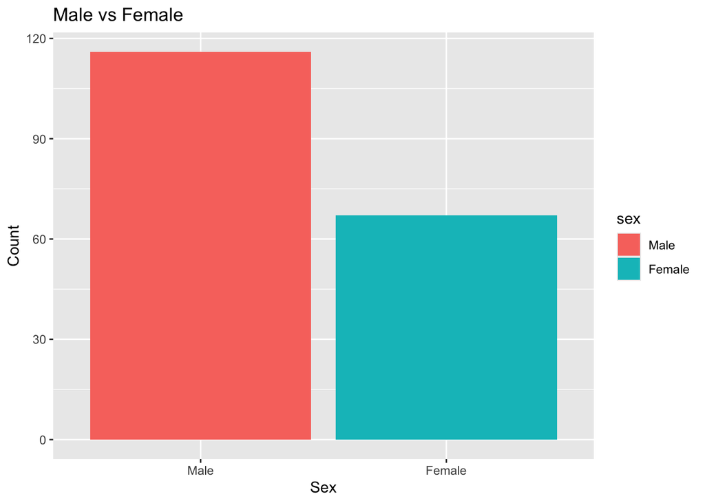

```r
#install.packages("ggplot2")
library(ggplot2)
library(dplyr)


# Sex bar plot ---------

sex_bar_plot <- ggplot(df5, aes(x=sex, fill = sex)) + geom_bar() + labs(
    title = "Male vs Female",
    x = "Sex",
    y = "Count"
  )

sex_bar_plot
```

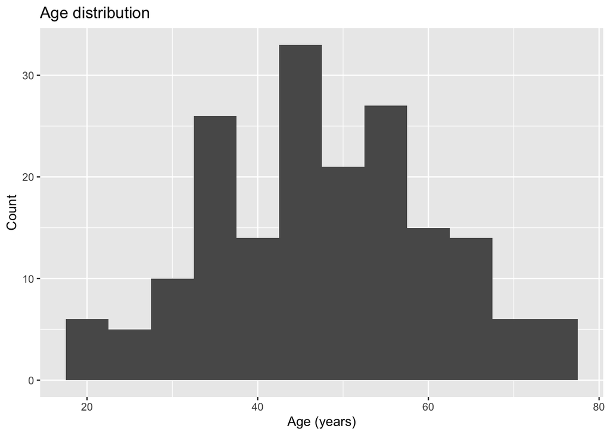

```r
# Age histogram ---------
age_histogram <- ggplot(df5, aes(x = age)) +
  geom_histogram(binwidth = 5) +
  labs(
    title = "Age distribution",
    x = "Age (years)",
    y = "Count"
  )

age_histogram
```

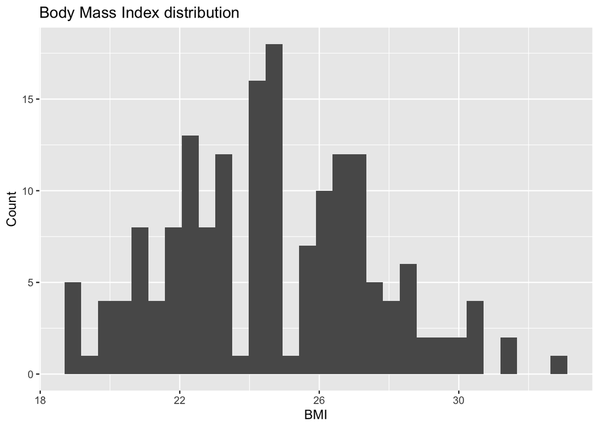

```r
# Bmi histogram --------
bmi_histogram <- ggplot(df5, aes(x = bmi)) +
  geom_histogram() +
  labs(
    title = "Body Mass Index distribution",
    x = "BMI",
    y = "Count"
  )

bmi_histogram
```

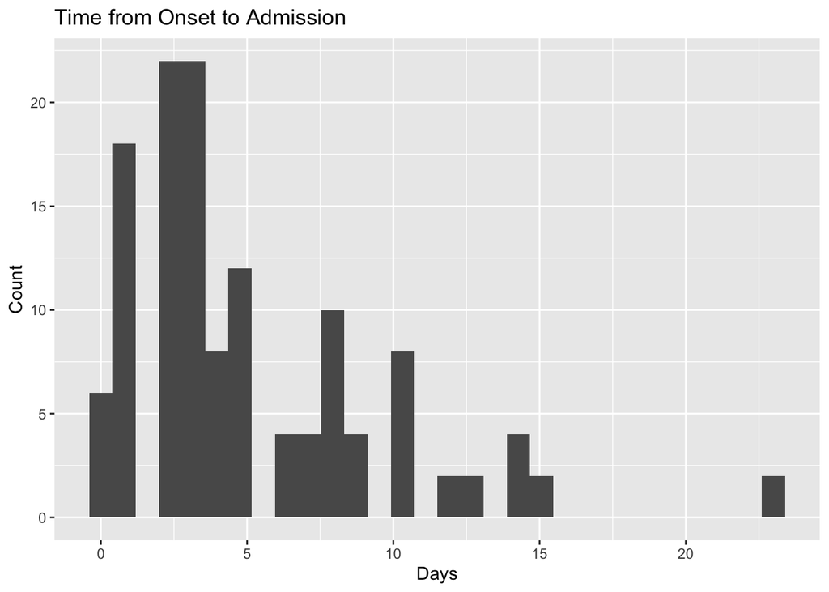

```r
# Onset to admission --------
onset_to_admission_histogram <- ggplot(df5, aes(x = onset_to_admission)) +
  geom_histogram() +
  labs(
    title = "Time from Onset to Admission",
    x = "Days",
    y = "Count"
  )

onset_to_admission_histogram
```

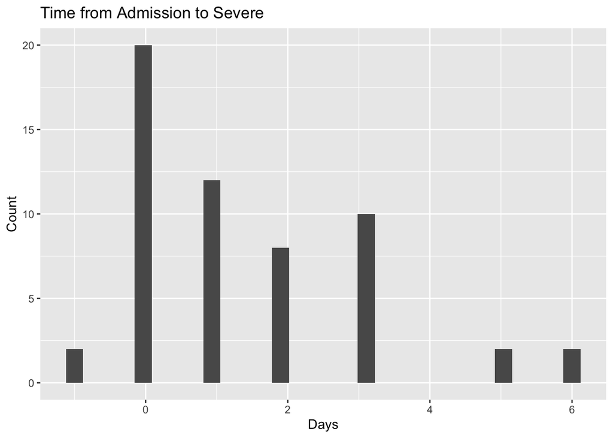

```r
# Admission_to_severe --------
admission_to_severe_histogram <- ggplot(df5, aes(x = admission_to_severe)) +
  geom_histogram() +
  labs(
    title = "Time from Admission to Severe",
    x = "Days",
    y = "Count"
  )

admission_to_severe_histogram
```

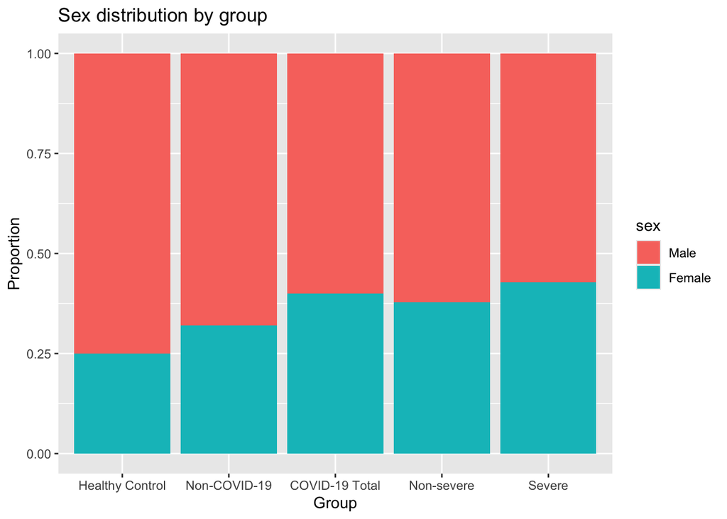

```r
# Group comparisons --------

#group is the COVID status!

#Sex by group -----
sex_by_group <- ggplot(df5, aes(x = group, fill = sex)) +
  geom_bar(position = "fill") +
  labs(
    title = "Sex distribution by group",
    x = "Group",
    y = "Proportion"
  )

sex_by_group
```

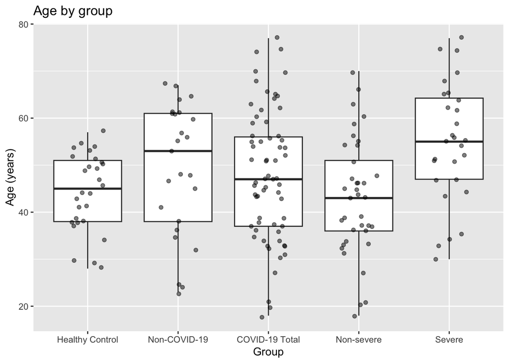

```r
#Age by group -----
age_by_group <- ggplot(df5, aes(x = group, y = age)) +
  geom_boxplot(outlier.shape = NA) +
  geom_jitter(width = 0.2, alpha = 0.5) +
  labs(
    title = "Age by group",
    x = "Group",
    y = "Age (years)"
  )


age_by_group
```

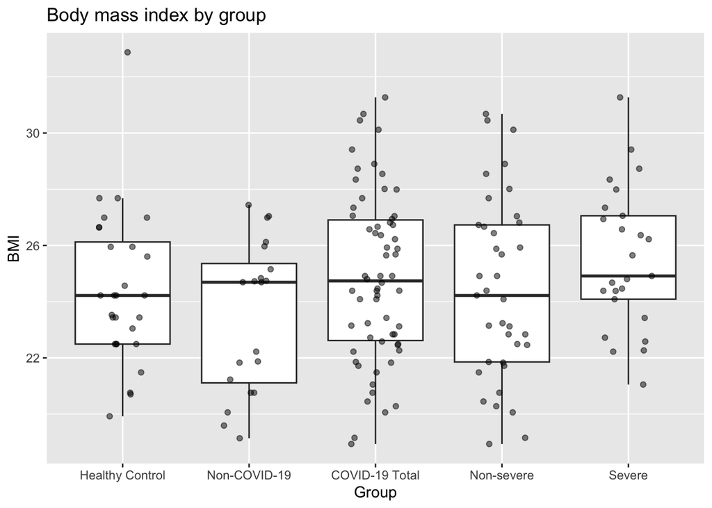

```r
#BMI by group -----
bmi_by_group <- ggplot(df5, aes(x = group, y = bmi)) +
  geom_boxplot(outlier.shape = NA) +
  geom_jitter(width = 0.2, alpha = 0.5) +
  labs(
    title = "Body mass index by group",
    x = "Group",
    y = "BMI"
  )

bmi_by_group
```

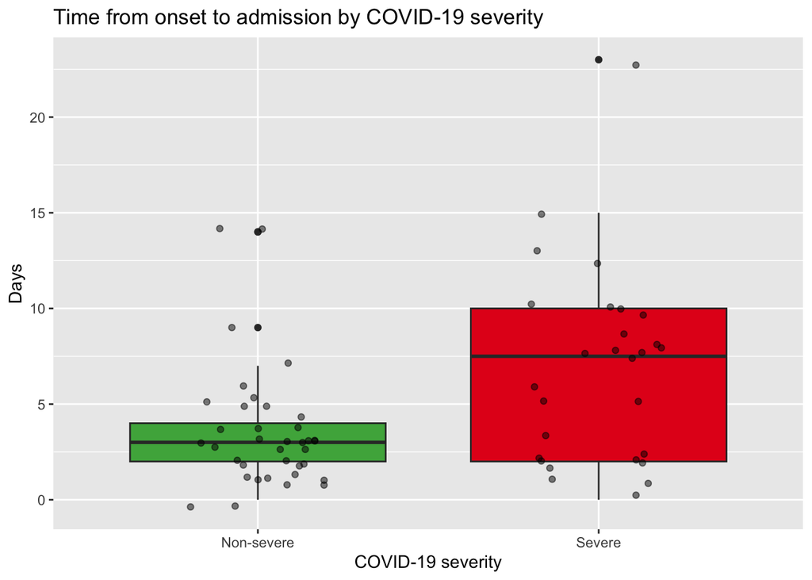

```r
# Time variables by severity
#Time from symtpom onset to hospital admission was explored only among COVID-19 patients, as this variable was not defined for healthy controls or non-COVID individuals.
covid_df <- df5 %>%
  filter(group %in% c("Non-severe", "Severe"))

ggplot(covid_df, aes(x = group, y = onset_to_admission, fill = group)) +
  geom_boxplot() +
  geom_jitter(width = 0.2, alpha = 0.5) +
  scale_fill_manual(
    values = c(
      "Non-severe" = "#4DAF4A",  # green
      "Severe" = "#E41A1C"       # red
    )
  ) +
  labs(
    title = "Time from onset to admission by COVID-19 severity",
    x = "COVID-19 severity",
    y = "Days"
  ) +
  theme(legend.position = "none")
```

Exploratory data analysis was performed to describe the demographic and clinical characteristics of the study population. Sex, age and BMI distributions were first explored using descriptive statistics and graphical representations. Age and BMI showed reasonable ranges without evident implausible values. Some clinical time variables, such as time from symptom onset to hospital admission and time from admission to severe disease, were only defined for subsets of COVID-19 patients, reflecting the study design rather than random missingness.

# Exercise 2

## Exercise 2.1

Reproduce Supplementary Figure 1 using the data without modifying or removing any observations. Use the same variables and groupings as in the original figure.

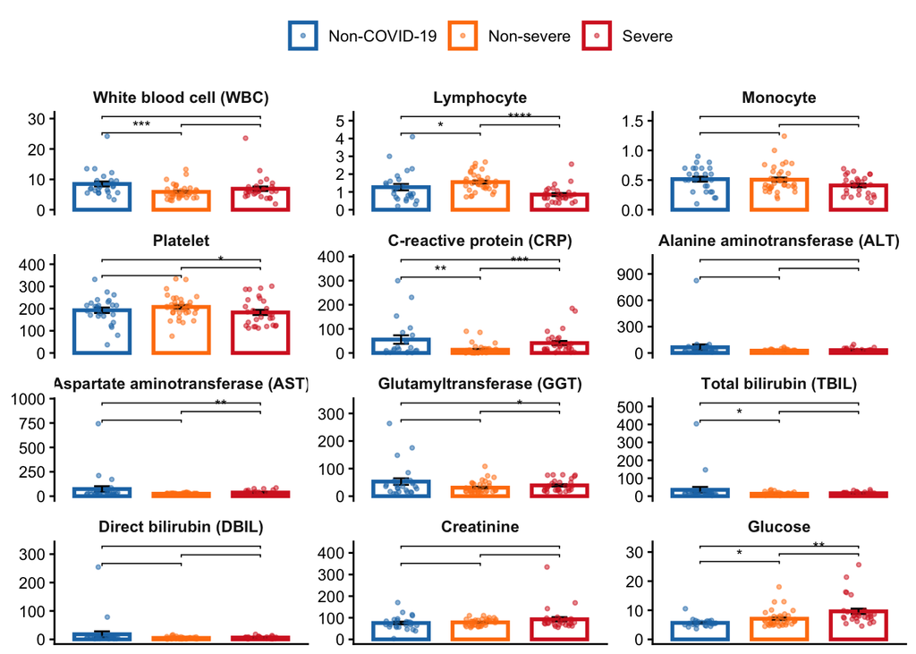

```r
library(ggplot2)
library(tidyr)
library(dplyr)
library(readxl)
library(ggpubr)
library(readr)
library(janitor)


# Pivot data to "Long" format so all variables can be plotted at once
#Pivot means changing the shape (layout) of a dataset, wuthout changing the values. Only reorganizewhere the values sit in the table.

df <- read_excel("../1-s2.0-S0092867420306279-mmc1.xlsx", sheet = 2)
df <- clean_names(df) #to have clean_names available, use library(janitor)!!
df_new_variables <- df %>%
  mutate(
    group = case_when(
      group_d %in% c(0, 1) ~ "Non-COVID-19",
      group_d == 2 ~ "Non-severe",
      group_d == 3 ~ "Severe",
      TRUE ~ NA_character_
    ),
    group = factor(group, levels = c("Non-COVID-19", "Non-severe", "Severe"))
  )

# Variables (columns) to plot (AND order to match the original figure)
marker_order <- c(
  "wbc_count_109_l",
  "lymphocyte_count_109_l",
  "monocyte_count_109_l",
  "platelet_count_109_l",
  "crp_i_mg_l",
  "alt_j_u_l",
  "ast_k_u_l",
  "ggt_l_u_l",
  "tbil_m_mmol_l",
  "dbil_n_mmol_l",
  "creatinine_mmol_l",
  "glucose_mmol_l"
)

vars <- marker_order

# Nice facet labels
lab <- c(
  wbc_count_109_l = "White blood cell (WBC)",
  lymphocyte_count_109_l = "Lymphocyte",
  monocyte_count_109_l = "Monocyte",
  platelet_count_109_l = "Platelet",
  crp_i_mg_l = "C-reactive protein (CRP)",
  alt_j_u_l = "Alanine aminotransferase (ALT)",
  ast_k_u_l = "Aspartate aminotransferase (AST)",
  ggt_l_u_l = "Glutamyltransferase (GGT)",
  tbil_m_mmol_l = "Total bilirubin (TBIL)",
  dbil_n_mmol_l = "Direct bilirubin (DBIL)",
  creatinine_mmol_l = "Creatinine",
  glucose_mmol_l = "Glucose"
)

#Some of the vars contain NA, and we cannot plot that, so as the exercise say that we cannot remove anything, convert NA into values.
df_fix <- df_new_variables %>%
  mutate(across(all_of(vars), ~ readr::parse_number(as.character(.))))
  #mutate modifies existing columns or create new ones, and apply this trans formation to all 12 markers.
  # (.) means the current colunm being processed, as.character() forces the column to be treated as text. readr::parse_number extracts the numeric part of a string.

dlong <- df_fix %>%
    select(group, all_of(vars)) %>% #this keeps only the group and the 12 clinical variables listed in vars.
  pivot_longer( #the pivot_longer() needs all values to be same type (numeric)
    cols = all_of(vars), #stacks all 12 markers columns into one column
    names_to = "Marker", #stores their names in Marker
    values_to = "Value" #stores the measurements in Value
    ) %>%
  mutate(
    Marker = factor(Marker, levels = marker_order, labels = lab[marker_order])
  )
#levels= orders the markers the way I want, and without it, they would be alphabetically ordered.
#labels = lab [marker_order] replaces ugly variable names with human-readable titles.

#The code above transforms my dataset into a format where, each row = one measurement, each group = patient group, each marker = clinical value (like wbc, crp...) and each value = numeric value of that variable

# Pairwise comparisons (stars) -
comps <- list( #each element of the listis a pair of group names, so compare both groups.
  c("Non-COVID-19", "Non-severe"),
  c("Non-severe", "Severe"),
  c("Non-COVID-19", "Severe")
)

# One plot, 12 panels (ordered like the article)
p <- ggplot(dlong, aes(x = group, y = Value, color = group)) +
  # Add the bars representing the Mean
  stat_summary(
    fun = "mean",
    geom = "bar",
    fill = "white",
    linewidth = 1,
    width = 0.7
  ) +
  # Add the Error Bars (Standard Error)
  stat_summary(
    fun.data = "mean_se",
    geom = "errorbar",
    width = 0.2,
    color = "black"
  ) +
  # Add the individual jittered points
  geom_jitter(width = 0.2, alpha = 0.5, size = 0.8) +
  # Create the multi-panel grid
  facet_wrap(~Marker, ncol = 3, scales = "free_y") +
  # Statistical comparisons (stays the same)
  stat_compare_means(
    comparisons = comps,
    method = "wilcox.test",
    label = "p.signif",
    hide.ns = TRUE,
    size = 3,
    label.y.npc = "top"
  ) +
  # Manual colors for the group outlines
  scale_color_manual(
    values = c(
      "Non-COVID-19" = "#1f77b4",
      "Non-severe"   = "#ff7f0e",
      "Severe"       = "#d62728"
    )
  ) +
  # Styling and Cleanup
  theme_classic() +
  theme(
    axis.title = element_blank(),
    axis.text.x = element_blank(),
    axis.ticks.x = element_blank(),
    legend.title = element_blank(),
    strip.background = element_blank(),
    strip.text = element_text(face = "bold"),
    legend.position = "top",
  )

# Save the plot
ggsave("SuppFig1_2_1.png", p, width = 14, height = 12, dpi = 300)
p
```

## Exercise 2.2

Identify and handle outliers using an appropriate and well-justified method (e.g. removal, transformation, or robust statistics).

Reproduce Supplementary Figure 1 after outlier handling and discuss how and why the results change.

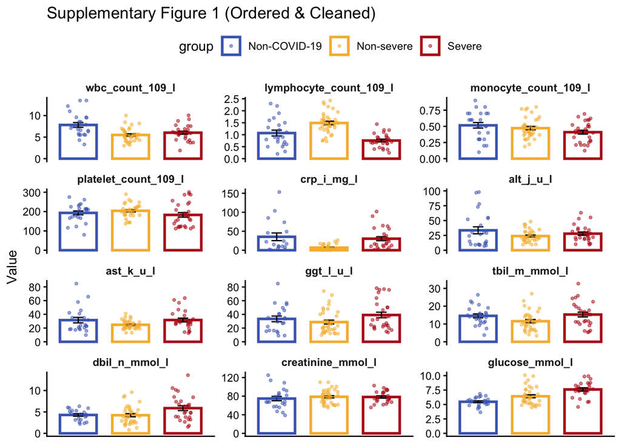

```r
#Seeing the plot above, we can observe that there are many dots high above the rest of the group. To deal with them, we can: Remove, Transform (log the data pulls extreme outliers closer to the mean, making the distribution more normal), or use robust statistics ( use median and IQR instead of mean and SD. By using the median, this is more robust because it is not pulled away by a single extreme value)

# REMOVAL ---------------
#install.packages("ggstatsplot")
#install.packages("tidyverse")
#install.packages("patchwork")
library(tidyverse)
library(ggstatsplot)
library(patchwork)
library(readxl)
library(janitor)

mydata<- read_excel("../1-s2.0-S0092867420306279-mmc1.xlsx", sheet = 2)
mydata <- clean_names(mydata)
# Define the variables in the EXACT order you want them to appear in the grid

ordered_vars <- c(
  "wbc_count_109_l", "lymphocyte_count_109_l", "monocyte_count_109_l",
  "platelet_count_109_l", "crp_i_mg_l", "alt_j_u_l",
  "ast_k_u_l",
  "ggt_l_u_l",
  "tbil_m_mmol_l",
  "dbil_n_mmol_l",
  "creatinine_mmol_l",
  "glucose_mmol_l"
)

# Data Processing Pipeline
mydata_ordered <- mydata %>%
  # Grouping logic
  mutate(
    group = case_when(
      group_d %in% c(0, 1) ~ "Non-COVID-19",
      group_d == 2 ~ "Non-severe",
      group_d == 3 ~ "Severe",
      TRUE ~ NA_character_
    ),
    group = factor(group, levels = c("Non-COVID-19", "Non-severe", "Severe"))
  ) %>%
  filter(!is.na(group)) %>%

  # Convert measurements to numeric
  mutate(across(all_of(ordered_vars), as.numeric)) %>%
  select(group, all_of(ordered_vars)) %>%

  # Pivot to long format
  pivot_longer(cols = -group, names_to = "measurement", values_to = "value") %>%

  # Convert measurement to a factor using the order defined above
  mutate(measurement = factor(measurement, levels = ordered_vars)) %>%

  # Outlier cleaning (per group and per marker)
  group_by(group, measurement) %>%
  mutate(
    q1 = quantile(value, 0.25, na.rm = TRUE),
    q3 = quantile(value, 0.75, na.rm = TRUE),
    iqr = q3 - q1,
    up = q3 + (1.5 * iqr),
    low = q1 - (1.5 * iqr),
    cleaned_value = ifelse(value > up | value < low, NA, value)
  ) %>%
  ungroup()
# Final Plotting
s <- ggplot(mydata_ordered, aes(x = group, y = cleaned_value, color = group)) +
  stat_summary(fun = "mean", geom = "bar", fill = "white", linewidth = 1, width = 0.7) +
  stat_summary(fun.data = "mean_se", geom = "errorbar", width = 0.2, color = "black") +
  geom_jitter(width = 0.2, alpha = 0.5, size = 0.8) +

  # Facet using the factor (which now follows our custom order)
  facet_wrap(~measurement, scales = "free_y", ncol = 3) +

  scale_color_manual(values = c(
    "Non-COVID-19" = "#4A69BD",
    "Non-severe"   = "#F6B93B",
    "Severe"       = "#B71C1C"
  )) +
  theme_classic() +
  theme(
    strip.background = element_blank(),
    strip.text = element_text(face = "bold"), # Makes labels clearer
    legend.position = "top",
    axis.text.x = element_blank(),
    axis.ticks.x = element_blank()
  ) +
  labs(title = "Supplementary Figure 1 (Ordered & Cleaned)", y = "Value", x = NULL)

ggsave("SuppFig1_2_2.png", s, width = 14, height = 12, dpi = 300)
s
```

```r
#Count removed outliers
outlier_summary <- mydata_ordered %>%
  group_by(measurement, group) %>%
  summarise(
    total_samples = n(),
    outliers_removed = sum(is.na(cleaned_value) & !is.na(value)),
    percent_removed = (outliers_removed / total_samples) * 100
  ) %>%
  filter(outliers_removed > 0) # Only show markers that actually had outliers
view(outlier_summary)
```

The fact that the original paper kept these extreme values (original figure), suggest that they prioritized showing the full clinical range of COVID19, including extreme organ failure, rather than achieving a “normal” statistical distribution. This reproduction demonstrates that standard IQR cleaning focuses on the typical case but can make the remaining variance appear more pronounced when the axis is allowed to scale freely.

# Exercise 3

Create a heatmap of the biomarker data. Include group and gender as annotation variables.

```r
#As biomarkers have very different units, units must be scaled so all of them are compared ona relative basis. This is done in the pheatmap function to do the heatmap
#by grouping by group, allows to see if "severe" patients have a distinct color pattern compared to the "healthy" controls
#grouping by gender, helps identify if biomarker patterns are influenced by biological sex.

#install.packages("pheatmap")
library(pheatmap)
library(tidyverse)
library(ggplot2)

# 1. Take cleaned "mydata_ordered" and pivot it back to wide format
mydata_long <- mydata %>%
  select(patient_id_a, group = group_d, sex = sex_g, all_of(ordered_vars)) %>%
  mutate(across(all_of(ordered_vars), ~as.numeric(as.character(.)))) %>%
  pivot_longer(cols = all_of(ordered_vars),
               names_to = "measurement",
               values_to = "value") %>%
  drop_na(value)
heatmap_ready <- mydata_long %>%
  drop_na(value) %>%
  pivot_wider(names_from = measurement, values_from = value) %>%
  drop_na() # Heatmaps cannot handle NA values easily; pheatmap will fail

heatmap_ready <- heatmap_ready %>%
  mutate(
    group = case_when(
      group %in% c(0, 1) ~ "Non-COVID-19",
      group == 2 ~ "Non-severe",
      group == 3 ~ "Severe",
      TRUE ~ NA_character_
    ),
    group = factor(group, levels = c("Non-COVID-19", "Non-severe", "Severe")),

    sex = case_when(
      sex == 0 ~ "Female",
      sex == 1 ~ "Male",
      TRUE ~ as.character(sex)
    )
  )

# 2. Prepare Annotation
annotation_col <- heatmap_ready %>%
  select(group, sex) %>%
  as.data.frame()

# 3. Create the Matrix
matrix_to_plot <- heatmap_ready %>%
  select(all_of(ordered_vars)) %>%
  as.matrix()

# 4. Plot
## 1. Convert everything to standard data frames immediately
matrix_df <- as.data.frame(matrix_to_plot)
# Make sure group and sex are in my annotation data
# annotation_col <- heatmap_ready[rows_to_keep, ] %>%
#   select(group, sex) %>%
#   as.data.frame()

## 2. Handle the NAs (Outliers)
# Since I have 51 patients in my matrix, we need to make sure
# the annotation table also has exactly those 51 patients.
# rows_to_keep <- complete.cases(matrix_df)

# matrix_to_plot_clean <- matrix_df[rows_to_keep, ]
# annotation_col_clean <- annotation_col[rows_to_keep, , drop = FALSE]

## 3. Assign matching dummy names
patient_names <- paste0("Patient_", 1:nrow(matrix_to_plot))
rownames(matrix_to_plot) <- patient_names
rownames(annotation_col) <- patient_names

## 4. Check the counts
print(paste("Matrix rows (patients):", nrow(matrix_to_plot)))
```

```
## [1] "Matrix rows (patients): 85"
```

```r
print(paste("Annotation rows:", nrow(annotation_col)))
```

```
## [1] "Annotation rows: 85"
```

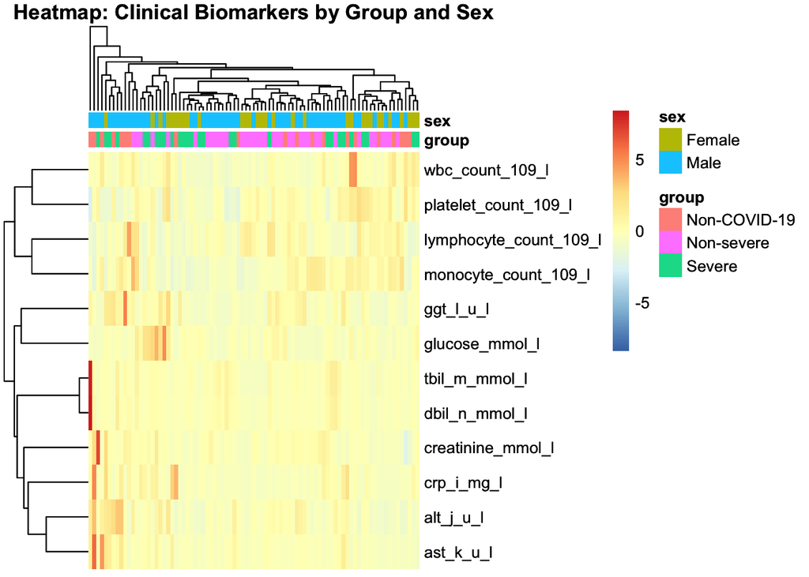

```r
## 5. Plot
h <- pheatmap(
  t(matrix_to_plot), # Biomarkers in rows
  scale = "row",     # Z-score scaling
  annotation_col = annotation_col,
  show_colnames = FALSE,
  main = "Heatmap: Clinical Biomarkers by Group and Sex"
)

h
```

```r
ggsave("Heatmap.png", h, width = 14, height = 12, dpi = 300)
```

# Conclusion

# session info

R version 4.5.2 (2025-10-31) Platform: aarch64-apple-darwin20 Running under: macOS Tahoe 26.2

Matrix products: default BLAS: /System/Library/Frameworks/Accelerate.framework/Versions/A/Frameworks/vecLib.framework/Versions/A/libBLAS.dylib LAPACK: /Library/Frameworks/R.framework/Versions/4.5-arm64/Resources/lib/libRlapack.dylib; LAPACK version 3.12.1

locale: [1] en_US.UTF-8/en_US.UTF-8/en_US.UTF-8/C/en_US.UTF-8/en_US.UTF-8

time zone: Europe/Madrid tzcode source: internal

attached base packages: [1] stats graphics grDevices utils datasets methods base

other attached packages: [1] pheatmap_1.0.13 patchwork_1.3.2 ggstatsplot_0.13.3 forcats_1.0.1  
[5] purrr_1.2.1 tibble_3.3.1 tidyverse_2.0.0 ggpubr_0.6.2  
[9] tidyr_1.3.2 ggplot2_4.0.1 htmltools_0.5.9 janitor_2.2.1  
[13] table1_1.5.1 lubridate_1.9.4 readr_2.1.6 stringr_1.6.0  
[17] dplyr_1.1.4 readxl_1.4.5 knitr_1.51

loaded via a namespace (and not attached): [1] gtable_0.3.6 xfun_0.55 bslib_0.9.0  
[4] bayestestR_0.17.0 insight_1.4.4 rstatix_0.7.3  
[7] paletteer_1.7.0 tzdb_0.5.0 vctrs_0.6.5  
[10] tools_4.5.2 generics_0.1.4 datawizard_1.3.0  
[13] pkgconfig_2.0.3 correlation_0.8.8 RColorBrewer_1.1-3  
[16] S7_0.2.1 RcppParallel_5.1.11-1 lifecycle_1.0.5  
[19] compiler_4.5.2 farver_2.1.2 textshaping_1.0.4  
[22] codetools_0.2-20 carData_3.0-5 snakecase_0.11.1  
[25] sass_0.4.10 yaml_2.3.12 Formula_1.2-5  
[28] pillar_1.11.1 car_3.1-3 jquerylib_0.1.4  
[31] cachem_1.1.0 statsExpressions_1.7.1 abind_1.4-8  
[34] tidyselect_1.2.1 digest_0.6.39 stringi_1.8.7  
[37] rematch2_2.1.2 labeling_0.4.3 fastmap_1.2.0  
[40] grid_4.5.2 cli_3.6.5 magrittr_2.0.4  
[43] utf8_1.2.6 broom_1.0.11 withr_3.0.2  
[46] scales_1.4.0 backports_1.5.0 timechange_0.3.0  
[49] rmarkdown_2.30 ggsignif_0.6.4 cellranger_1.1.0  
[52] ragg_1.5.0 hms_1.1.4 evaluate_1.0.5  
[55] parameters_0.28.3 rstantools_2.6.0 rlang_1.1.7  
[58] zeallot_0.2.0 glue_1.8.0 rstudioapi_0.17.1  
[61] jsonlite_2.0.0 effectsize_1.0.1 R6_2.6.1  
[64] systemfonts_1.3.1